# GSBS544 Lab 5

Author

Sahil Bains

Github Link: https://github.com/sbains2/GSBS544

## Part One: Data Exploration

The dataset we will study for this assignment contains information about health insurance costs for individuals with no dependents (children) in the United States. The information contained in the data is:

- Age of primary beneficiary
- Gender of primary beneficiary (only female, male recorded)
- Body mass index, providing an understanding of body, weights that are relatively high or low relative to height, objective index of body weight (kg / m ^ 2) using the ratio of height to weight, ideally 18.5 to 24.9
- Whether the beneficiary smokes
- The beneficiary’s residential area in the US, northeast, southeast, southwest, northwest.
- Individual medical costs billed by health insurance

Read in the dataset, and display some summaries of the data.

Fix any concerns you have about the data.

Make up to three plots comparing the response variable (charges) to one of the predictor variables. Briefly discuss each plot.

```python
import pandas as pd
import numpy as np
from plotnine import *
from sklearn import *
from sklearn.model_selection import train_test_split
from sklearn.linear_model import LinearRegression
from sklearn.metrics import mean_squared_error, r2_score

# Reading in the data and doing some preliminary checks
df = pd.read_csv('Insurance Costs.csv')
df.info()
df.describe() # no null values

# Making dummy variables for sex, region, smoking status - created but not used later
sex_dummies = pd.get_dummies(df['sex'])
region_dummies = pd.get_dummies(df['region'])
smoker_dummies = pd.get_dummies(df['smoker'], prefix='smoker')

df = pd.concat([df, sex_dummies, region_dummies, smoker_dummies], axis=1)
```

```
<class 'pandas.core.frame.DataFrame'>
RangeIndex: 431 entries, 0 to 430
Data columns (total 6 columns):
 #   Column   Non-Null Count  Dtype
---  ------   --------------  -----
 0   age      431 non-null    int64
 1   sex      431 non-null    object
 2   bmi      431 non-null    float64
 3   smoker   431 non-null    object
 4   region   431 non-null    object
 5   charges  431 non-null    float64
dtypes: float64(2), int64(1), object(3)
memory usage: 20.3+ KB
```

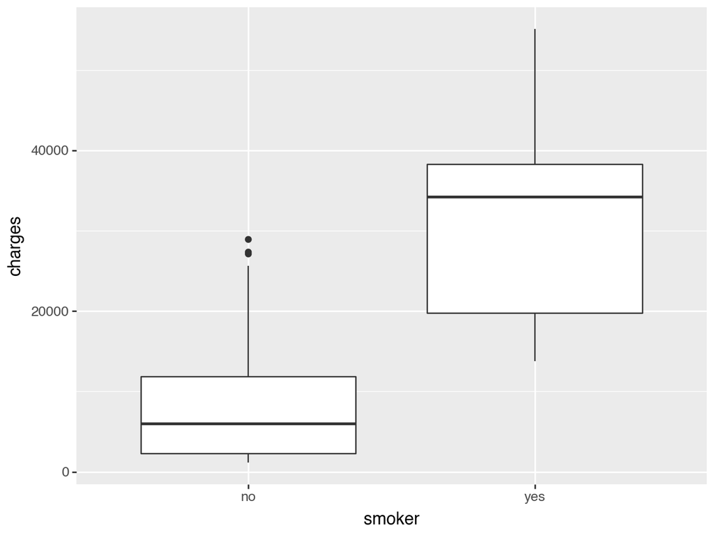

```python
# Plot 1
# Making plots comparing charges to one's smoking status
(
    ggplot(df, aes(x='smoker', y='charges'))
    + geom_boxplot()
)
```

*The first plot that I made was to determine the individual medical costs for individuals that smoked. I used a boxplot to determine the distribution of charges given one’s smoking status and found that those who smoked paid significantly more in individual medical costs. You’re able to see that the median and IQR are much higher for smokers.*

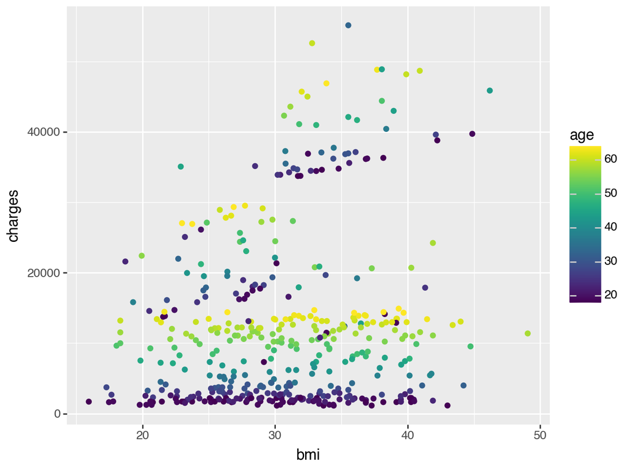

```python
# Making a plot to see the association between bmi and individual medical charges, with the color of each point being age
(
    ggplot(df, aes(x='bmi', y='charges', color='age'))
    + geom_point()
)
```

*The second plot I made was to determine the association between BMI and individual medical costs billed. One is able to see that charges rise with age. At higher BMI, there is greater dispersion between the charges.*

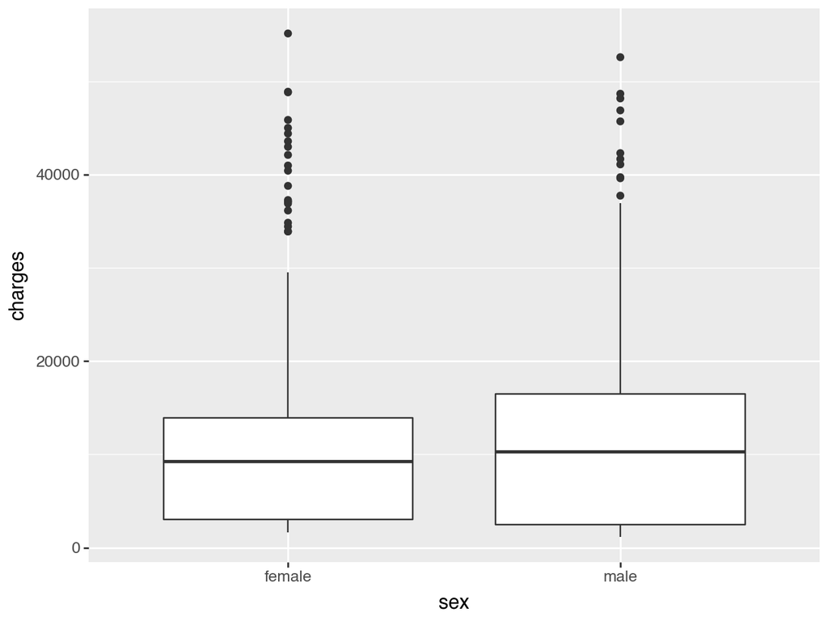

```python
# Plotting gender against individual medical charges
(
    ggplot(df, aes(x='sex', y='charges'))
    + geom_boxplot()
)
```

*The third plot I made was to look at the distribution of individual medical costs between genders. While the interquartile ranges are somewhat similar, differences in sex appear to be less significant relative to smoking.*

Part Two: Simple Linear Models a. Construct a simple linear model to predict the insurance charges from the beneficiary’s age. Discuss the model fit, and interpret the coefficient estimates.

2. Make a model that also incorporates the variable sex. Report your results.
3. Now make a model that does not include sex, but does include smoker. Report your results.
4. Which model (Q2 or Q3) do you think better fits the data? Justify your answer by calculating the MSE for each model, and also by comparing R-squared values.

```python
import math
# Defining target of medical cost and explanatory variable age.
y = df['charges']
X = df[['age']]

# Training the data
Xt, Xv, yt, yv = train_test_split(X, y, test_size=0.2, random_state=42)
m = LinearRegression()

# Fitting the model
train = m.fit(Xt, yt)

# finding R^2 score
r2 = m.score(Xv, yv)

# predicting
y_pred = m.predict(Xv)

mse = mean_squared_error(yv, y_pred)
rmse = math.sqrt(mse)

print(f'R^2 for charges dependent on age: {r2}, MSE: {mse}, RMSE: {rmse}')
print(m.coef_, m.intercept_)
```

```
R^2 for charges dependent on age: 0.1287424190241595, MSE: 141029548.95804176, RMSE: 11875.586257446063
[214.5460771] 4031.0413606972606
```

*In understanding the model fit for the predictor age on medical costs, we can see there is a weak association between the two variables with a R2 of .1287. In addition to this, there is a high model error indicated by the MSE value. In addition to this, we see that for every one year increase in age, there is a ~$214.55 increase in the individual costs billed by the health insurance.*

```python
# Defining target of medical cost and explanatory variable age, and gender.
y = df['charges']
X = df[['age', 'male']]

# Training the data
Xt, Xv, yt, yv = train_test_split(X, y, test_size=0.2, random_state=42)
m = LinearRegression()

# Fitting the model
train = m.fit(Xt, yt)

# finding R^2 score
r2 = m.score(Xv, yv)

# predicting
y_pred = m.predict(Xv)

mse = mean_squared_error(yv, y_pred)
rmse = math.sqrt(mse)

print(f'R^2 for charges dependent on age and sex: {r2}, MSE: {mse}, RMSE: {rmse}')
```

```
R^2 for charges dependent on age and sex: 0.10921970918963841, MSE: 144189669.48097306, RMSE: 12007.900294430041
```

```python
# Defining target of medical cost and explanatory variable age, and smoking status.
df['smoker_int'] = df['smoker'].map({'no': 0, 'yes': 1})
y = df['charges']
X = df[['age', 'smoker_int']]

# Training the data
Xt, Xv, yt, yv = train_test_split(X, y, test_size=0.2, random_state=42)
m = LinearRegression()

# Fitting the model
train = m.fit(Xt, yt)

# finding R^2 score
r2 = m.score(Xv, yv)

# predicting
y_pred = m.predict(Xv)

mse = mean_squared_error(yv, y_pred)
rmse = math.sqrt(mse)

print(f'R^2 for charges dependent on age and smoking status: {r2}, MSE: {mse}, RMSE: {rmse}')
```

```
R^2 for charges dependent on age and smoking status: 0.8316610385322897, MSE: 27248850.771853052, RMSE: 5220.04317720199
```

4. *From looking at the model metrics, we’re able to see that age and smoking status tended to explain the variation of medical costs the most, with an R2 value of 0.831, because smoking is primary driver. In addition to this, we see that this model also has the lowest mean squared error. When looking at the root mean squared error for this model, we see that on average, the model prediction error is around $5,200.*

Part Three: Multiple Linear Models Now let’s consider including multiple quantitative predictors.

1. Fit a model that uses age and bmi as predictors. (Do not include an interaction term, age*bmi, between these two.) Report your results. How does the MSE compare to the model in Part Two Q1? How does the R-squared compare?
2. Perhaps the relationships are not linear. Fit a model that uses age and age^2 as predictors. How do the MSE and R-squared compare to the model in P2 Q1?
3. Fit a polynomial model of degree 4. How do the MSE and R-squared compare to the model in P2 Q1?
4. Fit a polynomial model of degree 12. How do the MSE and R-squared compare to the model in P2 Q1?
5. According to the MSE and R-squared, which is the best model? Do you agree that this is indeed the “best” model? Why or why not?
6. Plot the predictions from your model in Q4 as a line plot on top of the scatterplot of your original data.

```python
# Defining target of medical cost and explanatory variable age, and bmi.
y = df['charges']
X = df[['age', 'bmi']]

# Training the data
Xt, Xv, yt, yv = train_test_split(X, y, test_size=0.2, random_state=42)
m = LinearRegression()

# Fitting the model
train = m.fit(Xt, yt)

# finding R^2 score
r2 = m.score(Xv, yv)

# predicting
y_pred = m.predict(Xv)

mse = mean_squared_error(yv, y_pred)
rmse = math.sqrt(mse)

print(f"R2: {r2}, MSE: {mse}, RMSE: {rmse}")
```

```
R2: 0.1706876553903791, MSE: 134239917.63105714, RMSE: 11586.19513175301
```

```python
# Defining target of medical cost and explanatory variable age, and age^2.
y = df['charges']
df['age_squared'] = df['age'] ** 2
X = df[['age', 'age_squared']]

# Training the data
Xt, Xv, yt, yv = train_test_split(X, y, test_size=0.2, random_state=42)
m = LinearRegression()

# Fitting the model
train = m.fit(Xt, yt)

# finding R^2 score
r2 = m.score(Xv, yv)

# predicting
y_pred = m.predict(Xv)

mse = mean_squared_error(yv, y_pred)
rmse = math.sqrt(mse)

print(f"R2: {r2}, MSE: {mse}, RMSE: {rmse}")
```

```
R2: 0.12914290286988972, MSE: 140964723.05883405, RMSE: 11872.856566927525
```

```python
# Defining target of medical cost and explanatory variable 4th degree polynomials.
y = df['charges']

# Defining 4th degree polynomials
df['age_squared'] = df['age'] ** 2
df['age_d3'] = df['age'] ** 3
df['age_d4'] = df['age'] ** 4

X = df[['age', 'age_squared', 'age_d3', 'age_d4']]

# Training the data
Xt, Xv, yt, yv = train_test_split(X, y, test_size=0.2, random_state=42)
m = LinearRegression()

# Fitting the model
train = m.fit(Xt, yt)

# finding R^2 score
r2 = m.score(Xv, yv)

# predicting
y_pred = m.predict(Xv)

mse = mean_squared_error(yv, y_pred)
rmse = math.sqrt(mse)

print(f"R2: {r2}, MSE: {mse}, RMSE: {rmse}")
```

```
R2: 0.14223541742722745, MSE: 138845451.4874121, RMSE: 11783.269982793914
```

*With comparing the model metrics of individual medical costs dependent on age and 4th degree polynomial of age and individual medical costs dependent on age, we can see that there is a very slightly higher R^2 score with the polynomial feature included. This means that a slightly higher portion of the variability in cost can be explained by the polynomial feature. In addition to this, the MSE is slightly lower with the polynomial feature included, indicating on average, there is a lower error rate.*

```python
# Defining target of medical cost and explanatory variable age up to the 12th degree polynomial.
y = df['charges']

# Defining 12th degree polynomials
df['age_squared'] = df['age'] ** 2
df['age_d3'] = df['age'] ** 3
df['age_d4'] = df['age'] ** 4
df['age_d5'] = df['age'] ** 5
df['age_d6'] = df['age'] ** 6
df['age_d7'] = df['age'] ** 7
df['age_d8'] = df['age'] ** 8
df['age_d9'] = df['age'] ** 9
df['age_d10'] = df['age'] ** 10
df['age_d11'] = df['age'] ** 11
df['age_d12'] = df['age'] ** 12

X = df[['age', 'age_squared', 'age_d3', 'age_d4', 'age_d5', 'age_d6', 'age_d7', 'age_d8', 'age_d9', 'age_d10', 'age_d11', 'age_d12']]

# Training the data
Xt, Xv, yt, yv = train_test_split(X, y, test_size=0.2, random_state=42)
m = LinearRegression()

# Fitting the model
m.fit(Xt, yt)

# finding R^2 score
r2 = m.score(Xv, yv)

# predicting
y_pred = m.predict(Xv)

mse = mean_squared_error(yv, y_pred)
rmse = math.sqrt(mse)

print(f"R2: {r2}, MSE: {mse}, RMSE: {rmse}")
```

```
R2: 0.1269752589670904, MSE: 141315597.2992292, RMSE: 11887.623702793979
```

*With comparing the model metrics of individual medical costs dependent on age and 12th degree polynomial of age and individual medical costs dependent on age, we can see that there is a slightly lower R^2 score with the 12th degree polynomial feature included. This means that a SLIGHTLY lower portion of the variability in cost can be explained by the polynomial feature. In addition to this, the MSE is slightly higher with the 12th degree polynomial feature included, indicating on average, there is a slightly higher error rate. An important consideration with the 12th degree polynomial is that they typically overfit and add little generalization compared to adding meaningful predictors like smoking status.*

*e. In understanding which model shows the best predictability, we look at which predictors scored the highest R^2 values and the lowest MSE, which turned out to be the model with smoking status included. We can see that with this feature included, there is a significantly higher value which shows that the variation in medical costs can be explained best by a person’s smoking status. In addition to this, there is a lower error rate, on average, that the model makes with predictions.*

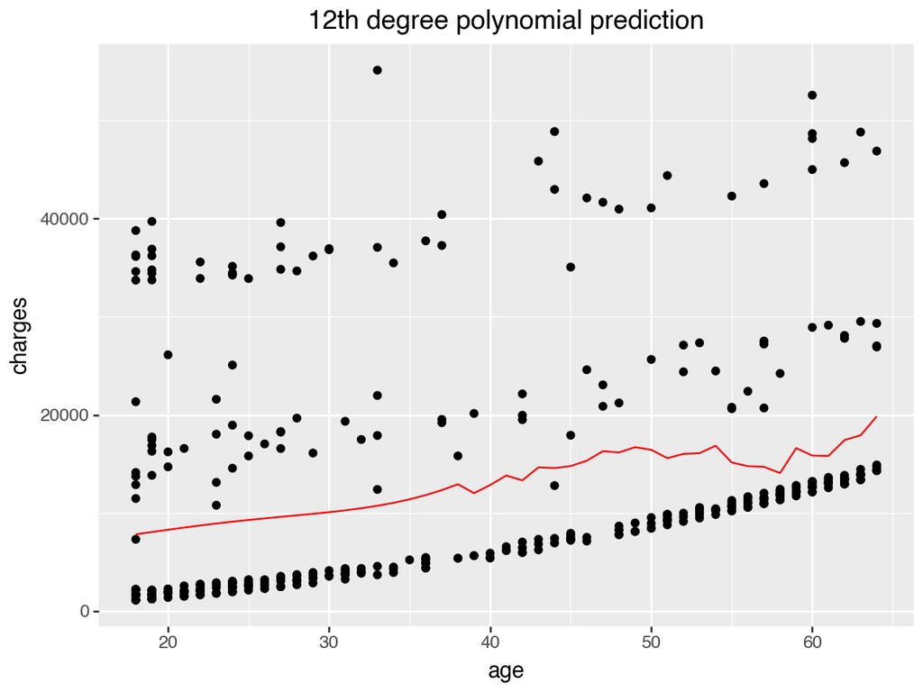

```python
# Making predictions for 12th degree age polynomial for series
df['predictions_d12'] = m.predict(df[['age', 'age_squared', 'age_d3', 'age_d4', 'age_d5', 'age_d6','age_d7', 'age_d8', 'age_d9', 'age_d10', 'age_d11', 'age_d12']])

df = df.sort_values('age')

(
    ggplot(df, aes(x='age', y='charges'))
    + geom_point()
    + geom_line(aes(x='age', y='predictions_d12'), color='red')
    + labs(
        title='12th degree polynomial prediction'
    )
)
```

Part Four: New data Great news! We’ve managed to collect data about the insurance costs for a few more individuals. You can find the new dataset here: https://www.dropbox.com/s/sky86agc4s8c6qe/insurance_costs_2.csv?dl=1

Consider the following possible models:

1. Only age as a predictor.
2. age and bmi as a predictor.
3. age, bmi, and smoker as predictors (no interaction terms)
4. age, and bmi, with both quantitative variables having an interaction term with smoker (i.e. the formula ~ (age + bmi):smoker)
5. age, bmi, and smokeras predictors, with both quantitative variables having an interaction term with smoker (i.e. the formula ~ (age + bmi)*smoker)

For each model, fit the model on the original data.

Then, use the fitted model to predict on the new data.

Report the MSE for each model’s new predictions. Based on this, which is the best model to use?

Make a plot showing the residuals of your final chosen model.

```python
# Loading in the new data
part4 = pd.read_csv('insurance_new.csv')

# Making dummy variables for sex, region, smoking status
sex_dummies = pd.get_dummies(part4['sex'])
region_dummies = pd.get_dummies(part4['region'])
smoker_dummies = pd.get_dummies(part4['smoker'], prefix='smoker')

part4 = pd.concat([part4, sex_dummies, region_dummies, smoker_dummies], axis=1)

# Defining target of medical cost and explanatory variable age.
y = df['charges']
X = df[['age']]

# Training the data on the original data
Xt, Xv, yt, yv = train_test_split(X, y, test_size=0.2, random_state=42)
m = LinearRegression()

# Fitting the model on the original data
train = m.fit(Xt, yt)

# finding R^2 score
r2 = m.score(Xv, yv)

# using the fitted model to predict on the new data
y_pred = m.predict(part4[['age']])
mse = mean_squared_error(part4['charges'], y_pred)
rmse = math.sqrt(mse)

print(f"MSE: {mse}, RMSE: {rmse}")
```

```
MSE: 136891668.5836555, RMSE: 11700.071306776532
```

```python
# Defining target of medical cost and explanatory variable age and bmi.
y = df['charges']
X = df[['age', 'bmi']]

# Training the data on the original data
Xt, Xv, yt, yv = train_test_split(X, y, test_size=0.2, random_state=42)
m = LinearRegression()

# Fitting the model on the original data
train = m.fit(Xt, yt)

# finding R^2 score
r2 = m.score(Xv, yv)

# using the fitted model to predict on the new data
y_pred = m.predict(part4[['age', 'bmi']])
mse = mean_squared_error(part4['charges'], y_pred)
rmse = math.sqrt(mse)

print(f"MSE: {mse}, RMSE: {rmse}")
```

```
MSE: 133723221.99501032, RMSE: 11563.875734156361
```

*With the new model for age and bmi as predictors based on fitting the model on the original data and running predictions for the new data, we see that the MSE is 133723221.99*

```python
# Defining target of medical cost and explanatory variable age.
y = df['charges']

# Converting smoking status to ints so that interaction terms can be properly calculated
df['smoker_int'] = df['smoker'].map({'no': 0, 'yes': 1})
part4['smoker_int'] = part4['smoker'].map({'no': 0, 'yes': 1})

# Defining interaction term for both original df and new
df['age_smoker'] = df['age'] * df['smoker_int']
df['bmi_smoker'] = df['bmi'] * df['smoker_int']

part4['age_smoker'] = part4['age'] * part4['smoker_int']
part4['bmi_smoker'] = part4['bmi'] * part4['smoker_int']

X = df[['age', 'bmi', 'smoker_int']]

# Training the data on the original data
Xt, Xv, yt, yv = train_test_split(X, y, test_size=0.2, random_state=42)
m = LinearRegression()

# Fitting the model on the original data
train = m.fit(Xt, yt)

# finding R^2 score
r2 = m.score(Xv, yv)

# using the fitted model to predict on the new data
y_pred = m.predict(part4[['age', 'bmi', 'smoker_int']])
mse = mean_squared_error(part4['charges'], y_pred)
rmse = math.sqrt(mse)

print(f"MSE: {mse}, RMSE: {rmse}")
```

```
MSE: 35709591.8537108, RMSE: 5975.750317216308
```

*With the new model with age, bmi, and smoker, based on fitting the model on the original data and running predictions for the new data, we see that the MSE is 35709591.85*

```python
# Defining target of medical cost and explanatory variable age.
y = df['charges']

X = df[['age_smoker', 'bmi_smoker']]

# Training the data on the original data
Xt, Xv, yt, yv = train_test_split(X, y, test_size=0.2, random_state=42)
m = LinearRegression()

# Fitting the model on the original data
train = m.fit(Xt, yt)

# finding R^2 score
r2 = m.score(Xv, yv)

# using the fitted model to predict on the new data
y_pred = m.predict(part4[['age_smoker', 'bmi_smoker']])
mse = mean_squared_error(part4['charges'], y_pred)
rmse = math.sqrt(mse)

print(f"MSE: {mse}, RMSE: {rmse}")
```

```
MSE: 48141116.16994963, RMSE: 6938.379938425802
```

```python
# Defining target of medical cost and explanatory variable age.
y = df['charges']

X = df[['age', 'bmi', 'smoker_int', 'age_smoker', 'bmi_smoker']]

# Training the data on the original data
Xt, Xv, yt, yv = train_test_split(X, y, test_size=0.2, random_state=42)
m = LinearRegression()

# Fitting the model on the original data
train = m.fit(Xt, yt)

# finding R^2 score
r2 = m.score(Xv, yv)

# using the fitted model to predict on the new data
y_pred_best = m.predict(part4[['age', 'bmi', 'smoker_int', 'age_smoker', 'bmi_smoker']])
e4_mse = mean_squared_error(part4['charges'], y_pred_best)
rmse = math.sqrt(e4_mse)

print(f"R2: {r2}, MSE: {e4_mse}, RMSE: {rmse}")
```

```
R2: 0.875853904294608, MSE: 21692136.756151754, RMSE: 4657.4818041675435
```

*We can see that the best model, with considering all the interactions between the predictor variables, is that model that includes the full interaction terms (age * smoker, bmi * smoker) AND the predictor variables age and bmi.*

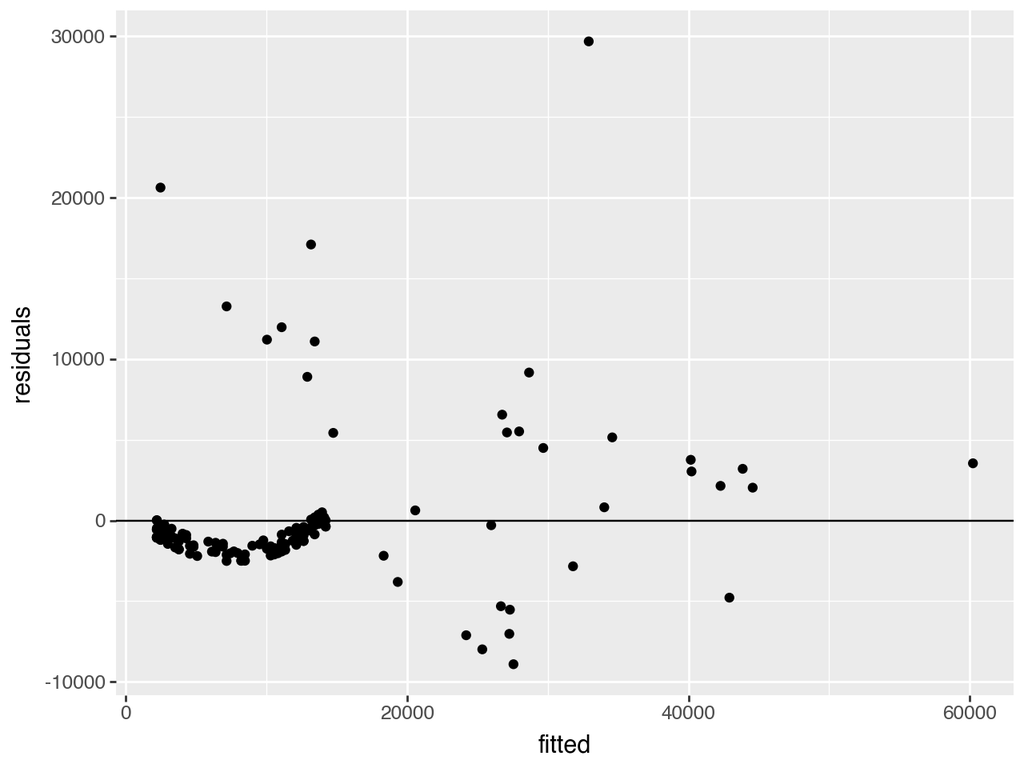

```python
# Making a plot showing the residuals for the best model, with the full interaction
# Creating a new column for the predicted fitted model
part4['fitted'] = y_pred_best


# Creating new column for the residuals
part4['residuals'] = part4['charges'] - part4['fitted']

(
    ggplot(part4, aes('fitted', 'residuals'))
    + geom_point()
    + geom_hline(yintercept=0)
)
```

Part Five: Full Exploration Using any variables in this dataset, and any polynomial of those variables, find the model that best predicts on the new data after being fit on the original data.

Make a plot showing the residuals of your final chosen model.

```python
# Creating a final model based on all the best predictors

# Creating quadratic polynomial for bmi
df['bmi_squared'] = df['bmi'] ** 2
part4['bmi_squared'] = part4['bmi'] ** 2

# Defining target of medical cost and explanatory variable age.
y = df['charges']
X = df[['age', 'bmi', 'bmi_squared', 'smoker_int', 'age_smoker', 'bmi_smoker']]

# Training the data on the original data
Xt, Xv, yt, yv = train_test_split(X, y, test_size=0.2, random_state=42)
m = LinearRegression()

# Fitting the model on the original data
train = m.fit(Xt, yt)

# finding R^2 score
r2 = m.score(Xv, yv)

# using the fitted model to predict on the new data
y_pred_final = m.predict(part4[['age', 'bmi', 'bmi_squared', 'smoker_int', 'age_smoker', 'bmi_smoker']])
mse = mean_squared_error(part4['charges'], y_pred_final)
rmse = math.sqrt(mse)

print('Improvement in model versus part 4:', e4_mse - mse)
```

```
Improvement in model versus part 4: 135731.22364375368
```

We’re able to see that from the positive value by subtracting the explored model’s MSE from part 4 model’s MSE, part 5 model’s has a lower MSE, indicating on average that there’s a lower model error rate.

Plotting the residuals

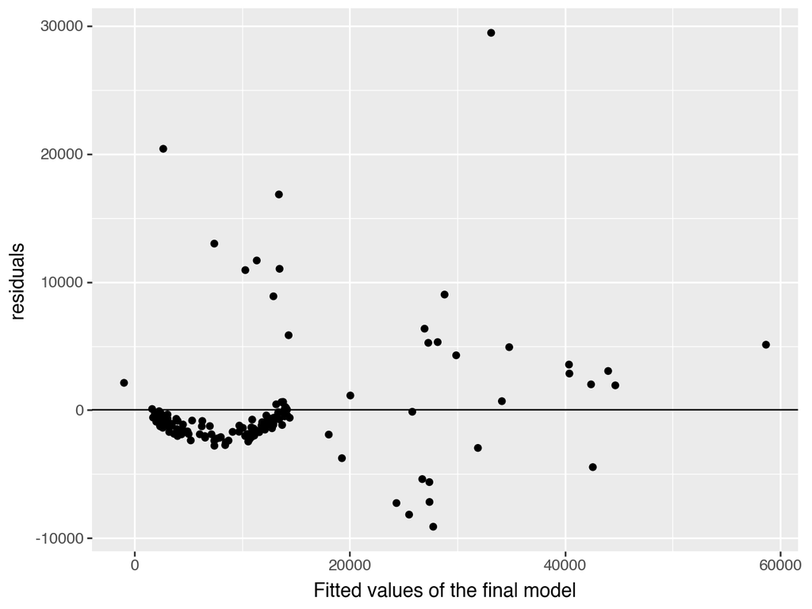

```python
# Making a plot showing the residuals for the best model, with the full interaction
# Formatting the final fitted predictions into column for neatness
part4['fitted_final'] = y_pred_final
# Creating new column for the residuals
part4['residuals'] = part4['charges'] - part4['fitted_final']

(
    ggplot(part4, aes('fitted_final', 'residuals'))
    + geom_point()
    + geom_hline(yintercept=0)
    + labs(
        x='Fitted values of the final model'
    )
)
```

Conclusion: The residual plot shows that most points are centered around 0, indicating that it is a reasonably good fit. However, at higher fitted values, there is more variation and spread in the residuals. Overall, the model explains the data accurately, but can be further refined to handle the larger charges more effectively.